# Crime and Community

**Group Member 1 Name:** Khang V. Tran **Group Member 1 SID:** 25181590

**Group Member 2 Name:** Christian Philip Hoeck **Group Member 2 SID:** 3035385003

The crime and communities dataset contains crime data from communities in the United States. The data combines socio-economic data from the 1990 US Census, law enforcement data from the 1990 US LEMAS survey, and crime data from the 1995 FBI UCR. More details can be found at https://archive.ics.uci.edu/ml/datasets/Communities+and+Crime+Unnormalized.

Once downloaded (from bCourses), the data can be loaded as follows.

```r
library(readr)
CC <- read_csv("../data_files/crime_and_communities_data.csv")
print(dim(CC))
```

```
[1] 1994  125
```

```r
y <- CC$ViolentCrimesPerPop
X <- subset(CC, select = -c(ViolentCrimesPerPop))
```

# Part 1) Dataset Exploration - Feature Creating and Engineering

In this section, we provide a thorough exploration of the features of the dataset.

- Which variables are categorical versus numerical?
- What are the general summary statistics of the data? How can these be visualized?
- Is the data normalized? Should it be normalized?
- Are there missing values in the data? How should these missing values be handled?
- Can the data be well-represented in fewer dimensions?

## Missing Data Processing

The first and foremost of any data science project should be missing value handling. This is a common issue since missing value almost always exist in the process of data sampling. There are more than one way to fill in the mssing value. For example, using mean or median of the feature. However, such practice is reasonable if and only if the missing portion is not high and systematic (data in one groups of related features has high missing rate). In the coming up processes, we are assessing features with high missing rate and remove them before any further work.

check if target y contains missing data

```r
any(is.na(y))
```

```
[1] FALSE
```

check if any of the features contains missing data

```r
any(is.na(X))
```

```
[1] TRUE
```

Now, as we have detected that there exist feature(s) in X that contain NA, the next step is to find and remove features with high proportion of NA (50% or above) and remove them all together before process those that have an acceptable number of NA

```r
get_na_perc <- function(x, n){
  return(sum(is.na(x))/n)
}

get_na_perc_all_features <- function(features){
  n = nrow(features)
  perc <- apply(X = features, MARGIN = 2, FUN = function(x) sum(is.na(x))/n)
  return(perc)
}

get_feature_high_na <- function(features, threshold){
  perc <- get_na_perc_all_features(features)
  return(names(perc[perc >= threshold]))
}

feature_high_na <- get_feature_high_na(X, .5)
print(feature_high_na)
```

```
 [1] "LemasSwornFT"         "LemasSwFTPerPop"      "LemasSwFTFieldOps"    "LemasSwFTFieldPerPop"
 [5] "LemasTotalReq"        "LemasTotReqPerPop"    "PolicReqPerOffic"     "PolicPerPop"
 [9] "RacialMatchCommPol"   "PctPolicWhite"        "PctPolicBlack"        "PctPolicHisp"
[13] "PctPolicAsian"        "PctPolicMinor"        "OfficAssgnDrugUnits"  "NumKindsDrugsSeiz"
[17] "PolicAveOTWorked"     "PolicCars"            "PolicOperBudg"        "LemasPctPolicOnPatr"
[21] "LemasGangUnitDeploy"  "PolicBudgPerPop"
```

```r
# X <- X %>% dplyr::select(-feature_high_na)
X <- X %>% dplyr::select(-feature_high_na)
```

Now that we have only feature with none or a low number of NA left, let’s replace the mising values with the median, and check for missing data again

```r
X <- X %>% mutate_all(function(x) ifelse(is.na(x), median(x, na.rm = TRUE), x))
any(is.na(X))
```

```
[1] FALSE
```

## Examine Categorical vs. Quantitative data

```r
str(X)
```

By examine the structure of the data using str() (result not shown due to exessive printing) we can explore the datatype of each feature. So far, we are be able to see that there is no factor type, which means there is no string categorical feature. Neither str() nor apply(class) shows any factor. Just to be certain, I examine the documentation from the source (UC Irvine): https://archive.ics.uci.edu/ml/datasets/Communities+and+Crime+Unnormalized and did not find any character nor factor class. However, more examination is needed since there might be numerical catergorical data.

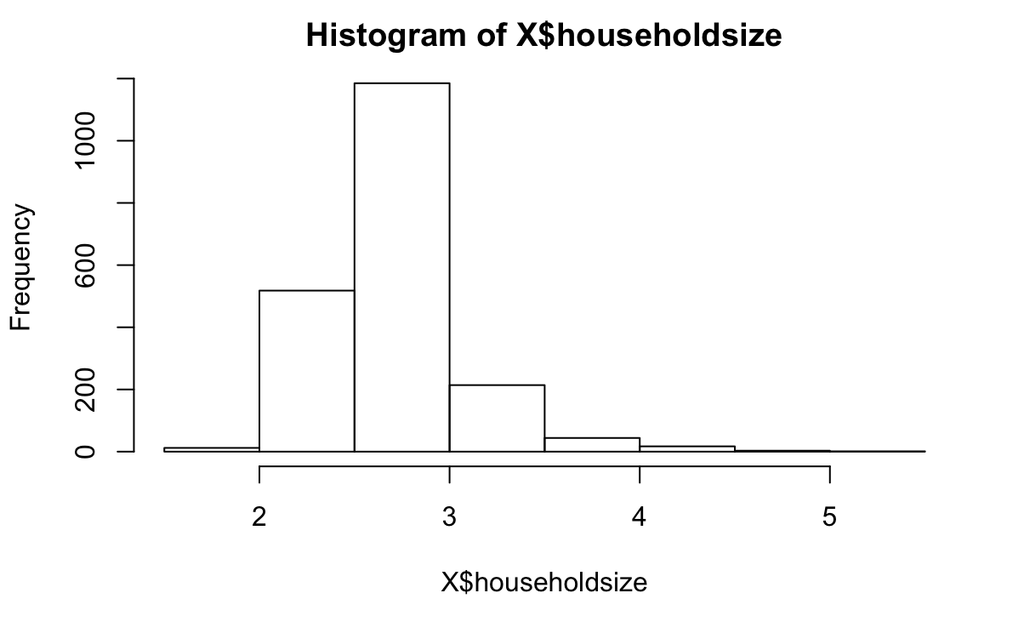

```r
hist(X$householdsize)
```

```r
print(head(X$householdsize, n = 20))
```

```
 [1] 3.10 2.82 2.43 2.40 2.45 2.60 2.45 2.46 2.62 2.54 2.89 2.54 2.74 2.85 2.62 2.67 2.60 2.60 3.34 2.36
```

By plotting histogram, we can pick out some categorical-likely feature. One of them is $householdsize$. However, when verifying with the documentation, we see that $householdsize$ is actually the mean people per household (numeric - decimal). By printing out the first few values, we are able to confirm this. Therefore, it is not categorical

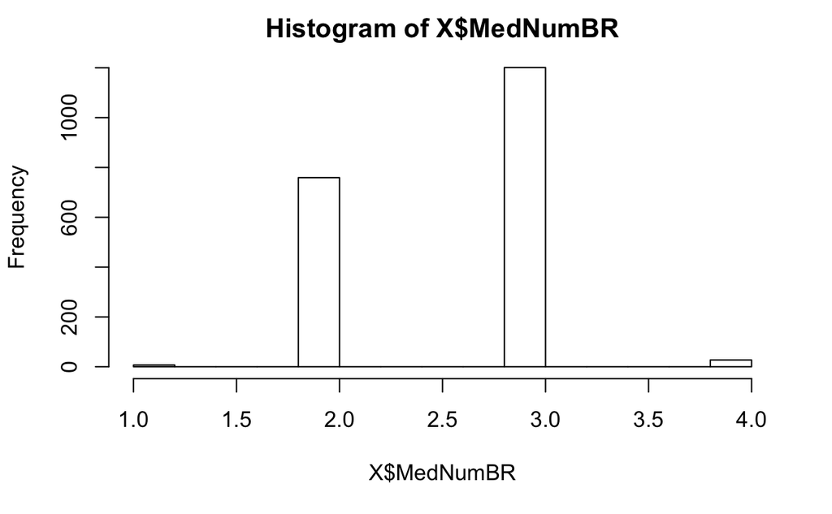

```r
hist(X$MedNumBR)
```

```r
print(head(X$MedNumBR))
```

```
[1] 3 3 3 3 2 3
```

The next candidate is $MedNumBR$. This is, indeed, categorical and we can confirm this by once again using histogram and by printing out the first few values. However, since this is numerical, it does not matter if this is categorical. We leave it as is.

There exist in the original data the feature of states, county code, and community code, which are catergorical. However, they are not included in the given data. On the other hads, all other quantitative features in the original data are. We can say that the data set is entirely quantitative.

## Summary Statistics

When speaking about crimes, there are factors that need to be taken into consideration. They are Unemployment, Children of Single Parent, Homelessness/Rent, and Poverty. Due to the high number of feature, we will only select a few feature that will give a very general idea about some of these factors

```r
interesting_features <- c("PctUnemployed", "NumKidsBornNeverMar", "MedRentPctHousInc", "PctPopUnderPov")

summary_stat <- function(features, selection){
  stats <- apply(X = features[, selection], MARGIN = 2, FUN = summary)
  return(stats)
}

summary_stat(X, interesting_features)
```

```
        PctUnemployed NumKidsBornNeverMar MedRentPctHousInc PctPopUnderPov
Min.         1.320000                0.00          14.90000        0.64000
1st Qu.      4.090000              146.25          24.30000        4.69250
Median       5.485000              361.00          26.20000        9.65000
Mean         6.023862             2041.45          26.32803       11.79593
3rd Qu.      7.430000             1070.25          28.10000       17.07750
Max.        23.830000           527557.00          35.10000       48.82000
```

From the summary, it is easy to spot the difference in unit and range of these chosen features. In one the next step, we will scale the data in order to remove the unit affect. Before that, let’s visualize some features to see if there is any pattern.

## Visualization

Due to such as massive number of feature, there is no way to visualize data from every feature without dimentionality reduction. In the next coming graphs, we only examine some groups of feature that will hopefully tell us something about the data.

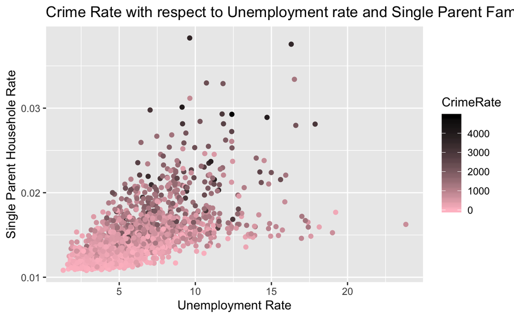

As you can see on the plot above, crime rate tends to be higher for area with higher unemployment rate and high single parent rate. However, to our surprised, the areas with the highest unemployment rate do not neccessarily have high crime rate. The three areas with highest unemployment rate have noticeably low crime rate. This interesting finding is contrast to our presumtion when starting the project. That is, high unemployment is an indicattor for high crime rate. In fact, in this visualization, single parent household rate is a much stronger indicator since almost all area with the high rate of single parent family also have higher crime.

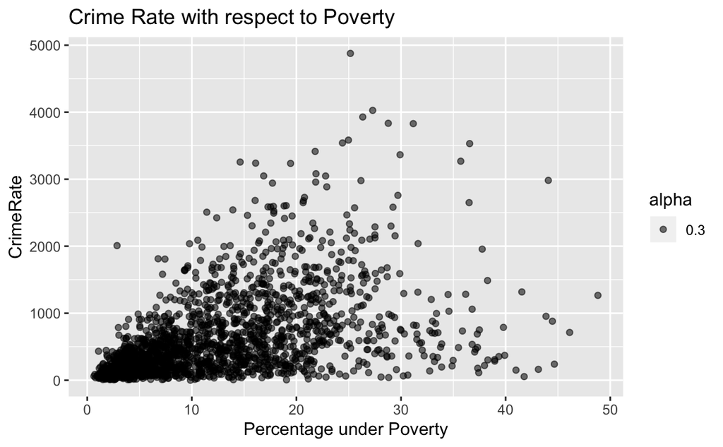

We plot another plot for crime rate with respect to poverty. Just like the previous plot, higher poverty tend to have higher crime. However, the collections of points (areas) with highest poverty rate have pretty low crime rate. We hope to find out more.

## Data Normalization - Scaling

As mentioned, after the previous step of examination, it is obvious that many features are different in nature. For example, some feautures are Percentage (PctForeignBorn, PctBornSameState). Some are counts (NumInShelters, population). Some are in US Dollars (MedRent, …). Each of the features have different range, scale, and unit. Such condition will affect how much each of the feature influence the predition later on .Therefore, it is highly crucial that we normalize the features.

```r
X <- scale(X)
```

## Dimensionality reduction - Principal Component Analysis

Apply PCA

```r
res.pca <- PCA(X = X,graph = F,ncp = 10)
```

```r
eig <- res.pca$eig
```

Visualize Eigenvalue

```r
eigvalue <- eig[1:15, "eigenvalue"]

barchart <- barplot(eigvalue, las = 1, border = NA,
                    names.arg = 1:length(eigvalue),
                    ylim = c(0, 1.1 * ceiling(max(eigvalue))),
                    ylab = "value",
                    xlab = "Eigenvalues - how much variance the corresponding PC captures",
                    main = "Scree plot")

points(barchart, eigvalue, pch = 19, col = "deepskyblue4")
```

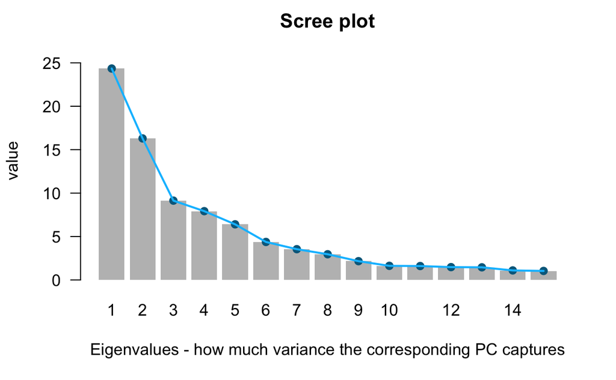

```r
lines(barchart, eigvalue, lwd = 2, col = "deepskyblue")
```

As you can see, each of the eigencalue represents the amount of variance in the dataset that was captured by the corresponding PC. Also, let’s examine the eigen value result overall

```r
head(eig, n = 7)
```

```
       eigenvalue percentage of variance cumulative percentage of variance
comp 1  24.343603              23.866278                          23.86628
comp 2  16.298258              15.978684                          39.84496
comp 3   9.134802               8.955689                          48.80065
comp 4   7.922395               7.767053                          56.56770
comp 5   6.406744               6.281121                          62.84883
comp 6   4.377330               4.291500                          67.14033
comp 7   3.544954               3.475445                          70.61577
```

With the given information above we can choose the number of component based on:

- Elbow method: the first 6 PCs
- Kaiser’s rule $\lambda_k > 1$: the first 20 PCs
- Jollie’s rule $\lambda_k > 0.7$: the first 30 PCs
- If we wish to keep the number of PCs that accumulatively capture 77% of the variance in the data, we can keep the first 10 PCs

[figure not shown]

```r
# names(PCs) # "coord"   "cor"     "cos2"    "contrib"
PCs <- res.pca$ind$coord
print(head(PCs, 3))
```

```
      Dim.1     Dim.2     Dim.3     Dim.4       Dim.5     Dim.6      Dim.7       Dim.8      Dim.9     Dim.10
1 11.139818  2.351282 -1.789758  1.807596  0.03109947  3.094648  1.2789742 -1.16483210  1.0360963 -0.4945979
2  6.344709 -1.673081 -1.897192  2.255860 -0.05696305  2.352737 -1.3071426  0.41199724 -0.1417800 -1.0425311
3  2.555890 -1.228925  1.888838 -2.156084  0.51900905 -3.296810 -0.9798917  0.07096829  0.2027569 -1.0705218
```

## Explore the target: Crime Rate per Population

After exploring the feature, we should also take the target Crime Rate per Population into consideration. First, let’s take a look at the summary and the density plot.

```r
summary(y)
```

```
   Min. 1st Qu.  Median    Mean 3rd Qu.    Max.
    0.0   161.7   374.1   589.1   794.4  4877.1
```

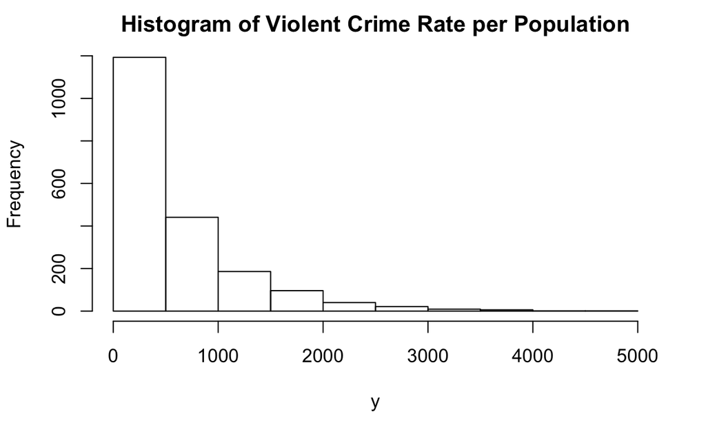

```r
hist(y, main = "Histogram of Violent Crime Rate per Population")
```

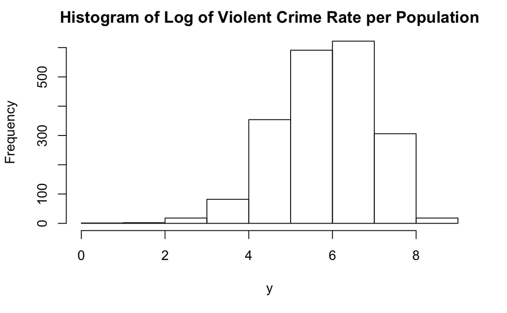

```r
y <- log(y)
y[is.infinite(y)] = 0
hist(y, main = "Histogram of Log of Violent Crime Rate per Population")
```

And now, we have a much better distribution. In the next steps, all operations will be done on this data.

# Part 2) Regression task

In this section, we use the techniques learned in class to develop a model to predict ViolentCrimesPerPop using the 124 features (or some subset of them) stored in $\mathbf{X}$. We try several different methods, and use model selection methods to determine which model is best. We keep a held-out test set to evaluate the performance of our model.

## Part 2.1) Train - Test - Validation Data Randomization

In order to perform hyperparameter tuning within a model and model selecting, we will apply three-way hold-out method. Meaning, the data will be randomized into:

- Train: 60% of the data
- Validation: 20% of the data
- Test: 20% of the data

The train set will be used in two steps. The first step is to perform intial training and visualization. The next one is to perform k-folds cross validation for hyperparameter tuning. We will apply multiple regression algorithms and determine the best configuration (hyper parameters) for each of them

The Validation set will be used for model selection. Meaning, we apply all of the algorithms in the previous step with theit optimal hyperparameters, then compare the result together to determine which one perform the best

Finally, we take the winning model the regress it onto the test set. This is equivalent to proceed into production

```r
set.seed(seed)
n <- nrow(X)
indices <- 1:n

# randomize 60% of the original data to be the train set
train_indices <- sample(x = indices, size = round(.6*n))
train_pcs <- PCs[train_indices, ]
train_features <- X[train_indices, ]
train_target <- y[train_indices]
train_data <- data.frame(cbind(train_features, train_target))
names(train_data)[ncol(train_data)] <- "LogViolentCrimesPerPop"

# randomize 20% of the original data to be the validation test
# (50% of the remaining data after sampling the train set)
validation_indices <- sample(x = indices[-train_indices],
                  size = round(.5*length(indices[-train_indices])))
validation_pcs <- PCs[validation_indices, ]
validation_features <- X[validation_indices, ]
validation_target <- y[validation_indices]

# use the rest of the data (20% of the original dataset) to be the final dataset
test_indices <- sample(x = indices[c(-train_indices,
                                     -validation_indices)])
test_pcs <- PCs[test_indices, ]
test_features <- X[test_indices, ]
test_target <- y[test_indices]
```

## Part 2.2) Training and Hyperparameter Tuning

### OLS Regression

```r
linear_model <- lm(formula = LogViolentCrimesPerPop ~ . ,
                   data = train_data)
```

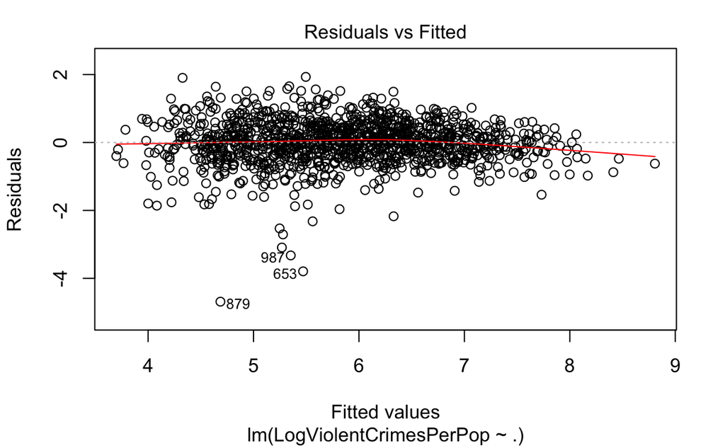

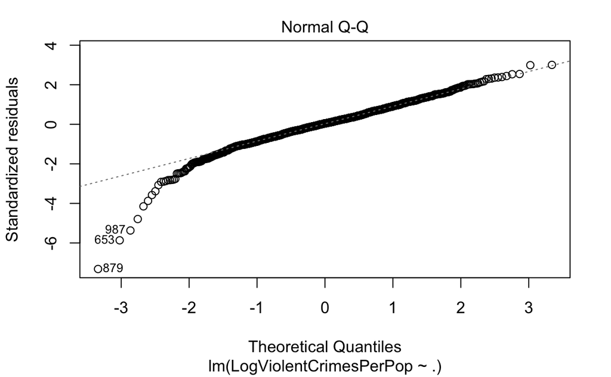

```r
plot(linear_model, which = 2)
```

Due to the nature of OLS, we get exactly one solution. There is no hyperparameter tuning

### Principal Componant Regression: tune number of component

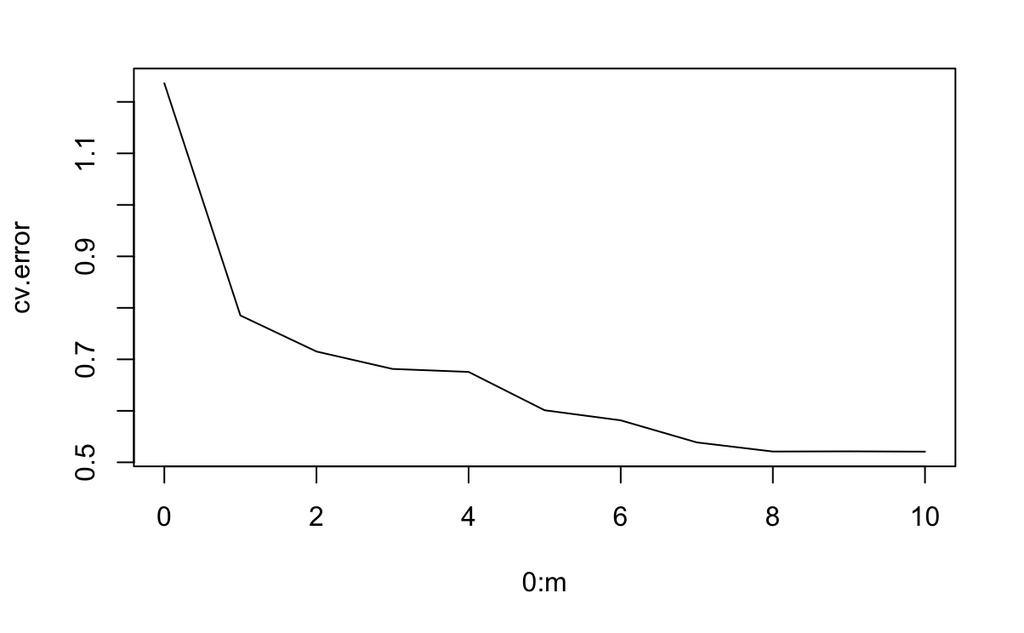

```r
set.seed(seed)
pcr_cv <- pcr.cv(train_features, train_target, k=num_folds,
       m = 10, groups=NULL, scale=F, eps=0.000001,
       plot.it = T)
```

```r
(optimal_num_pc <- unname(which(pcr_cv$cv.error == min(pcr_cv$cv.error))-1))
```

```
[1] 10
```

As we see above, the number of principal component that leads to the minimal error is 10

### Ridge Regression: tune Lambda term

```r
set.seed(seed)
(ridge_cv <- cv.glmnet(x = train_features, y = train_target, alpha = 0,
          nfolds = num_folds, parallel = T ))
```

```r
(optimal_lambda_ridge <- ridge_cv$lambda.min)
```

### Lasso Regression: tune Lambda term

```r
set.seed(seed)
(lasso_cv <- cv.glmnet(x = train_features, y = train_target, alpha = 1,
          nfolds = num_folds, parallel = T ))
```

```r
(optimal_lambda_lasso <- lasso_cv$lambda.min)
```

### K- Nearest Neighbors: tune number of neighbors

With regards to tunung, as the name nearest neighbor suggest, we choose to tune for the optimal number of neighbors. Higher number of neighbors has higher bias, but better robustness in the presence of outliers.

```r
set.seed(seed)

train_control <- trainControl(method = "cv",
                              number = num_folds)
num_neighbors = 1:15

tune_grid = expand.grid(k = num_neighbors)

(knn_cv <- train(x = train_pcs, y = train_target, method = "knn",
      trControl = train_control, metric = "RMSE",
      tuneGrid = tune_grid))
```

[output not shown]

```r
(temp <- knn_cv$results %>% filter(RMSE == min(RMSE)))

optimal_num_neighbors <- temp[, "k"]

optimal_rmse <- temp[, "RMSE"]
```

### Decision Tree

For decision tree, we firest aim to tune maximum number of split. However, the package rpart suggest we tune for maximum depth of tree, which has the same affect as tuning number of split.

```r
train_control <- trainControl(method = "cv",
                              number = num_folds)

max_depth = 3:14

tune_grid = expand.grid(maxdepth = max_depth)

(tree_cv <- train(x = train_features, y = train_target, method = "rpart2",
      trControl = train_control, metric = "RMSE", tuneGrid = tune_grid))
```

### Random Forest: tune number of features randomized, number of trees

In random forest, the first hyperparameter we should consider is the number of features to be randomly select for each iteration. Due to the extreme computation cost of random forest, we will be more conservative when select the values to tune. In this case, that is $\sqrt{p}\pm2$

```r
set.seed(seed)
train_control <- trainControl(method = "cv",
                              number = num_folds)

sqrt_p <- round(sqrt(ncol(train_features)))
mtry <- (sqrt_p - 2) : (sqrt_p + 2)
tune_grid = expand.grid(mtry = mtry)

(rf_cv <- train(x = train_features, y = train_target, method = "rf",
      trControl = train_control, metric = "RMSE",
      tuneGrid = tune_grid))
```

```r
(temp <- rf_cv$results %>% filter(RMSE == min(RMSE)))

optimal_mtry<- temp[, "mtry"]

optimal_rmse <- temp[, "RMSE"]
```

After tuning the number of features to be randomized, we move on to tune number of trees in each forest. Here we try 100 trees, 500 trees (default of caret), and 600 trees.

```r
tune_grid = expand.grid(mtry = 12)

for (num_tree in c(100, 500, 600)){
 rf_cv_temp <- train(x = train_features, y =train_target,
        method = "rf", metric = "RMSE",
        tree = num_tree,
        tuneGrid = tune_grid,
        trControl = train_control)

  print(rf_cv_temp$results %>% filter(RMSE == min(RMSE)))

}
```

## Part 2.3) Model Selection

### OLS Regression

```r
lm_model <- lm(formula = LogViolentCrimesPerPop ~., data = train_data)
lm_preds  <- predict(object = lm_model, newdata = data.frame(validation_features))
lm_mse <- mean((lm_preds - validation_target)^2)
```

### Principal Componant Regression

```r
library(pls)
library(analogue)
```

### Ridge Regression

```r
ridge_model <- glmnet(x = train_features, y = train_target,
                      alpha = 0,lambda = optimal_lambda_ridge)
ridge_preds <- predict(object = ridge_model, newx = validation_features)
ridge_mse <- mean((ridge_preds - validation_target)^2)
```

### Lasso Regression

```r
lasso_model <- glmnet(x = train_features, y = train_target,
                      alpha = 1, lambda = optimal_lambda_lasso)
lasso_preds <- predict(object = lasso_model, newx = validation_features)
lasso_mse <- mean((lasso_preds - validation_target)^2)
```

### K Nearest Neighbor Regression

```r
knn <- knn.reg(train = train_features, test = validation_features,
        y = train_target, k = optimal_num_neighbors)
knn_preds <- knn$pred
knn_mse <- mean((knn_preds - validation_target)^2)
```

### Decision Tree

```r
tree_model <- rpart(formula = LogViolentCrimesPerPop~. , data = train_data,
                    control = rpart.control(maxdepth = optimal_maxdepth) )
tree_preds <- predict(object = tree_model, newdata = data.frame(validation_features))
tree_mse <- mean((tree_preds - validation_target)^2)
```

### Random Forest

```r
set.seed(seed)
train_control <- trainControl(method = "none")
rf_model <- train(x = train_features, y = train_target,
                  method = "rf", trControl = train_control)
rf_preds <- predict(object = rf_model, newdata = validation_features)
rf_mse <- mean((rf_preds - validation_target)^2)
```

## Part 2.4) Final Model

Now we, random forest will train on the combination of validation set (80% of the data), and test on test set (the other 20% of the data). This is our final assesment before deployment.

```r
train_validation_features <- rbind(train_features, validation_features)
train_validation_target <- c(train_target, validation_target)
```

```r
set.seed(seed)
train_control <- trainControl(method = "none")
rf_model <- train(x = train_validation_features, y = train_validation_target,
                  method = "rf", trControl = train_control)
rf_preds <- predict(object = rf_model, newdata = test_features)
(rf_mse <- mean((rf_preds - test_target)^2))
```

[output not shown]

## Part 2.6) Final

We will train with the original features and target (100% of the data). The model will not be evaluated any further. This step is equivalent to deployment into production

```r
set.seed(seed)
train_control <- trainControl(method = "none")
final_model <- train(x = X, y = y,
                  method = "rf", trControl = train_control)
final_model
```

## Part 2.7) Conclusion and Future Step

```r
y <- exp(y)
y_classes <- cut(x = y, breaks = c(0, median(y), Inf), labels = c("below", "above"))
dat <- cbind(data.frame(X), data.frame(y_classes))
names(dat)[ncol(dat)] <- "Class"
```

```r
library(rpart.plot)
tree_model <- rpart(formula = Class~. , data = dat,
                    control = rpart.control(maxdepth = optimal_maxdepth) )
rpart.plot(tree_model)
```

[output not shown]

- In conclusion, this topic is a complicated and delicate one. Hence, it deserves in-depth examination from expert in the field of Social Welfare, Sociology, Economics, etc, but we agree that using the power of machine learning can greatly enhance the learning process to tackle the issue.